# M3 Lab

Vanessa Hong

# Part 0

**Please check the Canvas page for this assignment to see the specific questions (some are lengthy so I didn’t include them in their entirety in this document)**

## R packages

```r
# load tidyverse
library(tidyverse)
```

## Load data

```r
# load in the data
# verbose = T option will print out the name of the data frame that the obejct was stored with. This is the name you should use (you should see an object with this name in your environment)
load("/Users/vanes/Documents/SCHOOL/comp bio/BIOST2041/Data/acupuncture_data_reduced.RData", verbose = T)
```

```
## Loading objects:
##   data
```

## A. Make new factor variables

```r
# create the new variables I asked you for in the data (and save them in the data frame)

# One that calculates the change in headache severity between baseline and 3-month follow-up (pk2 - pk1). Note this is positive if headache severity increases and negative if headache severity decreases from baseline to 3-month follow-up. Call this variable headache_change
data$headache_change <- data$pk2 - data$pk1

# One that is a factor variable to label the acupuncture and control groups (0 = control, 1 = acupuncture treatment). Call this variable trt.
data$trt <- factor(data$group, levels = c(0, 1), labels = c('control', 'acupuncture treatment'))

# One that is a factor variable for sex (0 = male, 1 = female). Call this variable sex_f.
data$sex_f <- factor(data$sex, levels = c(0, 1), labels = c('male', 'female'))

head(data)
```

|  | id | age | sex | migraine | chronicity | acupuncturist | practice_id | group | pk1 | pk2 | pk5 | f1 | f2 | f5 | headache_change | trt | sex_f |
| --- | --- | --- | --- | --- | --- | --- | --- | --- | --- | --- | --- | --- | --- | --- | --- | --- | --- |
| 1 | 100 | 47 | 1 | 1 | 35 | 12 | 35 | 1 | 10.75 | NA | NA | 8 | 0 | 0.00 | NA | acupuncture treatment | female |
| 2 | 101 | 52 | 1 | 1 | 8 | 12 | 35 | 0 | 9.50 | NA | NA | 4 | 0 | 0.00 | NA | control | female |
| 3 | 104 | 32 | 1 | 1 | 14 | 12 | 35 | 0 | 16.00 | NA | 15.33333 | 12 | 0 | 13.33 | NA | control | female |
| 4 | 105 | 53 | 1 | 1 | 10 | 9 | 25 | 0 | 32.50 | 44.00 | NA | 21 | 18 | 0.00 | 11.5 | control | female |
| 5 | 108 | 56 | 1 | 1 | 40 | 9 | 25 | 0 | 16.50 | 17.50 | 23.25000 | 14 | 19 | 15.00 | 1.0 | control | female |
| 6 | 112 | 45 | 1 | 1 | 27 | 9 | 25 | 1 | 9.25 | 4.75 | 6.25000 | 15 | 8 | 13.00 | -4.5 | acupuncture treatment | female |

# Part 1

## A. Descriptives: Change in headache severity

Display an appropriate **numerical summary** of the **change in headache severity**. Create appropriate **visualizations** to display the distribution of the change in headache severity. Using these, **describe the distribution of the change in headache severity**. (Be sure to mention shape, center, and spread.)

```r
# numerical and visual summaries here
# we did things like this in lab 1, feel free to use that as a reference :)

data %>%
  summarise(mean = mean(headache_change, na.rm = TRUE),
            median = median(headache_change, na.rm = TRUE),
            min = min(headache_change, na.rm = TRUE),
            max = max(headache_change, na.rm = TRUE),
            q25 = quantile(headache_change, 0.25, na.rm = TRUE),
            q75 = quantile(headache_change,0.75, na.rm = TRUE),
            sd = sd(headache_change, na.rm = TRUE)) %>%
  mutate(IQR = q75 - q25)
```

| mean | median | min | max | q25 | q75 | sd | IQR |
| --- | --- | --- | --- | --- | --- | --- | --- |
| -4.714724 | -4 | -55.5 | 50.75 | -9.5 | 0.9375 | 11.72555 | 10.4375 |

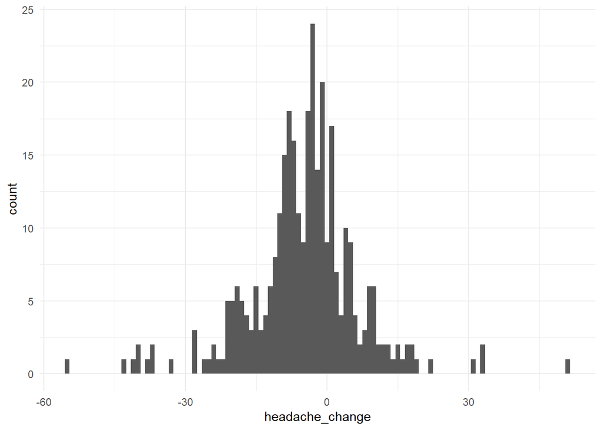

```r
# histogram
ggplot(data, aes(x = headache_change)) +
  geom_histogram(binwidth = 1) +
  theme_minimal()
```

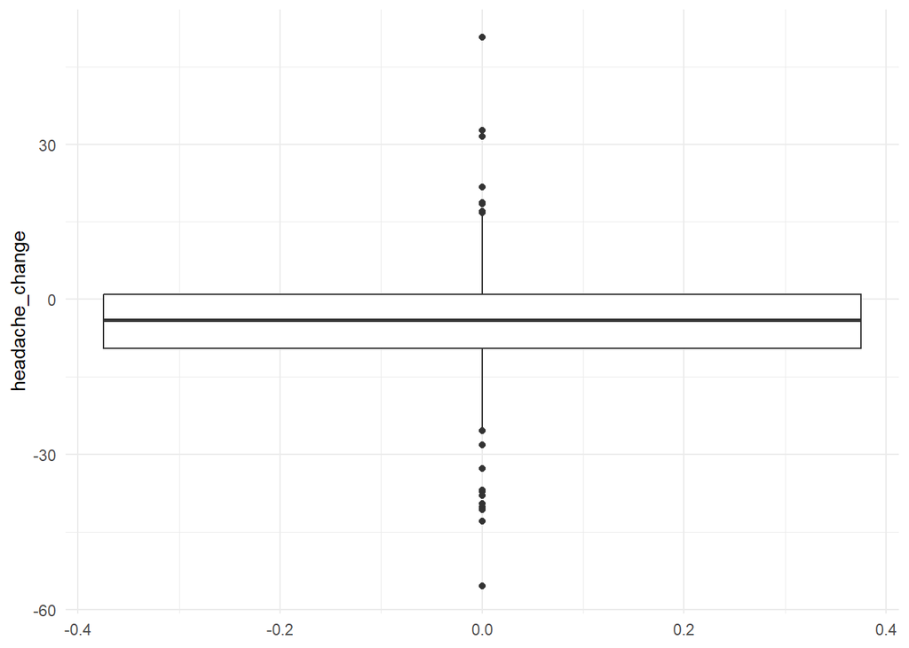

```r
# Boxplot
ggplot(data, aes(y = headache_change)) +
  geom_boxplot() +
  theme_minimal()
```

## B. Paired t test

Perform a **paired t-test using an alpha = 0.01 significance level** to see if there was a change in headache severity or not (i.e., was the mean change zero?).

```r
# check conditions of test
  # CLT conditions
  # assume random sample
  # assume independent data
  # is large sample size

# run a paired t test to test if the change in headache severity was 0 overall
# Perform a paired t-test on the headache_change variable
t.test(data$headache_change, mu = 0, alternative = "two.sided", conf.level = 0.99)
```

```
##
##  One Sample t-test
##
## data:  data$headache_change
## t = -7.2599, df = 325, p-value = 2.877e-12
## alternative hypothesis: true mean is not equal to 0
## 99 percent confidence interval:
##  -6.397393 -3.032054
## sample estimates:
## mean of x
## -4.714724
```

Write-up here (remember to include all of the components I asked you for here):

- **Check the conditions** to be able to use a paired t-test: Each subject provides two variables (headache before and after treatment) so the data is paired. The data also follows a relatively normal distribution, the sample size is sufficient, and it can be assumed to be randomly sampled.
- Descriptions of the null and alternative hypotheses in **words** (not symbols): Null: there is no change in headache severity before and after treatment. Alternative: there is a significant change in headache severity before and after treatment.
- The value of the **test statistic** from this sample: t = -7.2599
- The **p-value:** p = 2.877e-12
- An **interpretation** of the **corresponding confidence interval**: The 99% confidence interval is (-6.397393 -3.032054), and as this value does not contain 0, it indicates that the change in headache severity must be different than 0.
- Your **decision** about the null hypothesis (reject/fail to reject): Certainly, reject the null.
- A **conclusion** about the hypothesis test: There is significant evidence to conclude that the mean change in headache severity is not zero.

## C. Signed rank test

Perform a **signed rank test using an alpha = 0.01 significance level** to see if there was a change in headache severity or not (i.e., was the median change zero?).

```r
# conditions for a signed rank test

# signed rank test implementation
# wilcox.test(data$pk1, data$pk2, paired = TRUE)
wilcox.test(data$headache_change, mu = 0, alternative = "two.sided", conf.level = 0.99)
```

```
##
##  Wilcoxon signed rank test with continuity correction
##
## data:  data$headache_change
## V = 13150, p-value = 5.812e-15
## alternative hypothesis: true location is not equal to 0
```

Write-up here:

- **Check the conditions** to be able to use a signed rank test: Has paired observations, has assumed independence, has roughly symmetric distribution.
- Descriptions of the null and alternative hypotheses in **words** (not symbols): Null: The median change in headache severity is zero. Alternative: The median change in headache severity is significantly not zero.
- The **p-value**: p = 5.812e-15
- Your **decision** about the null hypothesis (reject/fail to reject): Reject the null hypothesis.
- A **conclusion** about the hypothesis test: There is significant evidence to conclude that the median change in headache severity is not zero.

## D. Summary of part 1

**Write a 1-3-sentence summary of your findings from part 1,** describing the increase/decrease in headache severity as if you were reporting these findings in a scientific paper. Also, comment on whether the findings change based on whether you use a parametric or nonparametric inference procedure.

Summary here: On average, participants experienced a significant decrease in headache severity from between baseline and 3-month follow-up, with a mean change of -4.71 (t = -7.2599, 99% CI (-6.397393, -3.032054), p-value = 2.877e-12). The Wilcoxon signed-rank test also indicated a significant decrease in headache severity (V = 13150, p-value = 5.812e-15). The consistent conclusions between both the parametric and nonparametric tests suggest that there is indeed a significant change in headache severity.

# Part 2

For this part, you will perform inference to compare the change in headache severity variable between the acupuncture treatment and control groups.

## A. Descriptives: Change in headache severity by treatment group

Display an appropriate **numerical summary** of the change in headache severity separately for the acupuncture treatment and control groups. Create appropriate **visualizations** to display the distribution of the change in headache severity separately for the acupuncture treatment and control groups. Using these, **compare the distributions of the change in headache severity for the acupuncture treatment and control groups**. (At a minimum compare the centers of these distributions.)

```r
# numerical and visual summaries here for change in headache severity
data %>%
  group_by(trt) %>%
  summarise(
    mean = mean(headache_change, na.rm = TRUE),
    median = median(headache_change, na.rm = TRUE),
    sd = sd(headache_change, na.rm = TRUE),
    IQR = IQR(headache_change, na.rm = TRUE),
    min = min(headache_change, na.rm = TRUE),
    max = max(headache_change, na.rm = TRUE)
  )
```

| trt | mean | median | sd | IQR | min | max |
| --- | --- | --- | --- | --- | --- | --- |
| control | -2.748366 | -2.75 | 10.83607 | 11.75 | -40.75 | 32.75 |
| acupuncture treatment | -6.453757 | -6.00 | 12.22871 | 10.25 | -55.50 | 50.75 |

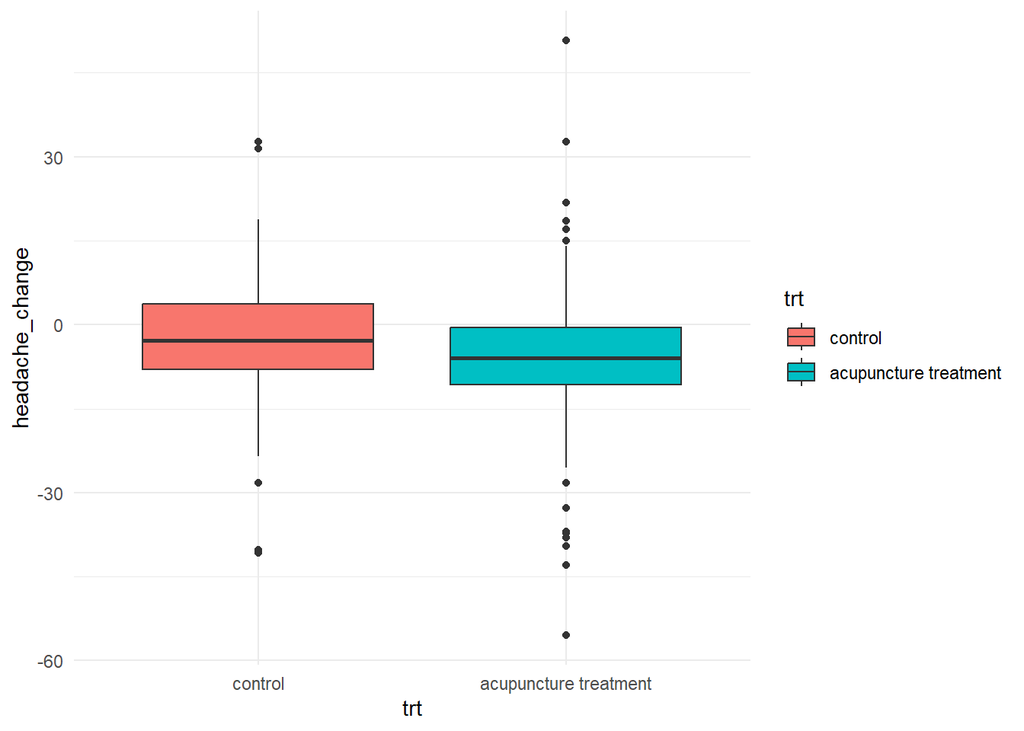

```r
ggplot(data, aes(x = trt, y = headache_change, fill = trt)) +
  geom_boxplot() +
  theme_minimal()
```

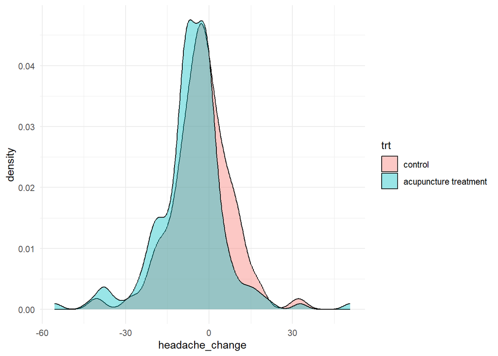

```r
# learned about density plots in another class, figured it would be useful here
ggplot(data, aes(x = headache_change, fill = trt)) +
  geom_density(alpha = 0.4) +
  theme_minimal()
```

Description of the variable: The mean of the control is -2.748366 and its median is -2.75, while the mean of the acupuncture treatment is -6.453757 and its median is -6.00. Looking at the boxplots, the acupuncture group has more outliers than the control– (-40.75, 32.75) for control and (-55.50, 50.75) for acupuncture. However they are both roughly normally distributed, with similar SDs and IQRs.

## B. Descriptives: Sex and age distributions by treatment group

Display an **appropriate numerical summary of age and sex** (make a new factor variable for sex) separately for the acupuncture treatment and control groups. Create appropriate **visualizations** to display the distribution of age and sex separately for the acupuncture treatment and control groups. (1pt)

- - In case the wording isn’t clear: In this question, please make
    - a numerical summary and visualization comparing the distribution of age in the treatment vs control group, and
    - a numerical summary and visualization comparing the distribution of sex in the treatment vs control group,

```r
# numerical and visual summaries here for sex
xtabs(~ trt + sex_f,data) %>% addmargins()
```

```
##                        sex_f
## trt                     male female Sum
##   control                 31    165 196
##   acupuncture treatment   33    172 205
##   Sum                     64    337 401
```

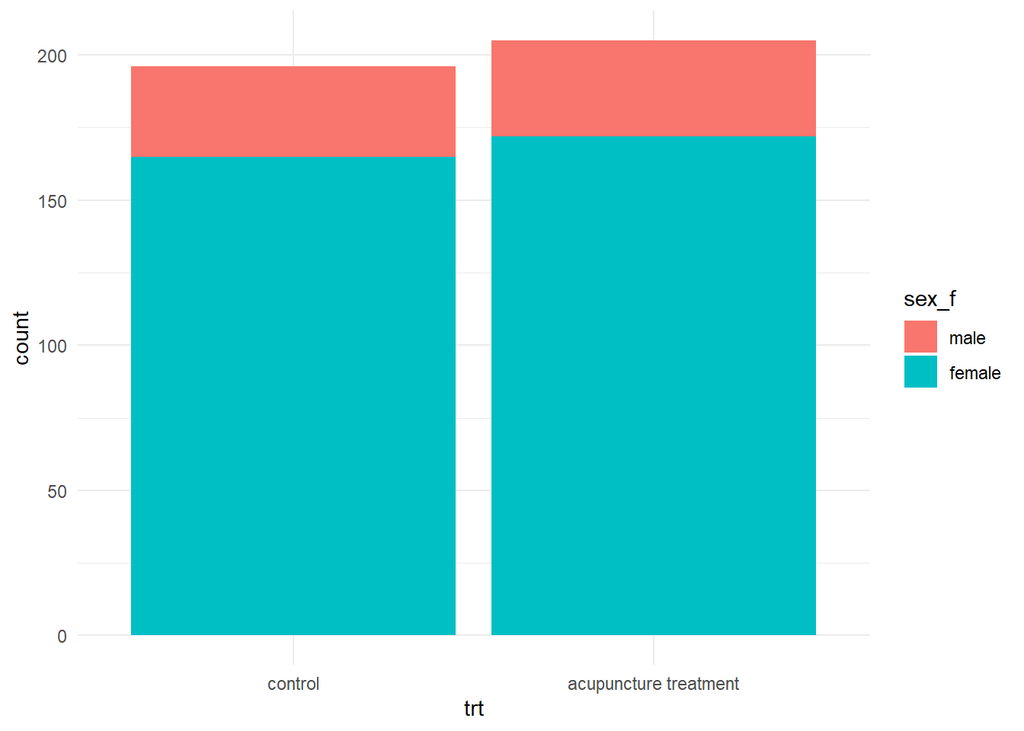

```r
# Bar plot for sex distribution by treatment group
ggplot(data, aes(x = trt, fill = sex_f)) +
  geom_bar() +
  theme_minimal()
```

```r
# numerical and visual summaries here for age
data %>%
  group_by(trt) %>%
  summarise(
    mean = mean(age, na.rm = TRUE),
    median = median(age, na.rm = TRUE),
    sd = sd(age, na.rm = TRUE),
    IQR = IQR(age, na.rm = TRUE),
    min = min(age, na.rm = TRUE),
    max = max(age, na.rm = TRUE)
  )
```

| trt | mean | median | sd | IQR | min | max |
| --- | --- | --- | --- | --- | --- | --- |
| control | 45.34184 | 49 | 11.47888 | 17.25 | 18 | 64 |
| acupuncture treatment | 45.72683 | 48 | 10.64920 | 12.00 | 18 | 65 |

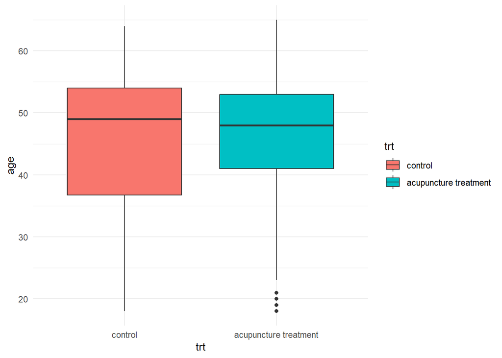

```r
# Boxplot of age by treatment group
ggplot(data, aes(x = trt, y = age, fill = trt)) +
  geom_boxplot() +
  theme_minimal()
```

Description here: There are significantly more females than there are males. However the sex proportions for both groups are very close, with 84.2% females in control group and 83.9% females in treatment. Likewise, the age distribution in both groups are very similar, the control mean being 45.34184 years and the treatment mean being 45.72683.

## C. Comment on 2B findings

**Comment on how the study design may have contributed to the results** in part 2B above. In the next section, we will test for differences in change in headache severity between the treatment and control groups. **How might your findings in 2B impact the conclusions** you are able to draw in the next section?

Comments about differences and how study design may have contributed here/possible impacts on next section: The two groups having very similar demographics is certainly beneficial for the study design. Because these two groups are almost identical in age and sex distribution, we can rule out demographics having any confounding impact on determining whether or not headache severity differed between the two groups.

## D. Two-sample t test

Perform a **two-sample t-test** (not assuming equal variances) using an **alpha = 0.05 significance level** to see if the change in headache severity differed by treatment group.

```r
# check conditions of test
  # two independent groups
  # normal distributions

# run a two sample t test to test if the change in headache severity was the same in each group
t.test(headache_change ~ trt, data = data)
```

```
##
##  Welch Two Sample t-test
##
## data:  headache_change by trt
## t = 2.9006, df = 324, p-value = 0.003979
## alternative hypothesis: true difference in means between group control and group acupuncture treatment is not equal to 0
## 95 percent confidence interval:
##  1.192266 6.218516
## sample estimates:
##               mean in group control mean in group acupuncture treatment
##                           -2.748366                           -6.453757
```

Write-up here:

- **Check the conditions** to be able to use a two-sample t-test: The two groups are independent, and the data is roughly normally distributed.
- Descriptions of the null and alternative hypotheses in **words** (not symbols): Null: the mean change in headache severity is the same for the acupuncture and control group (no treatment effect). Alternative: there is a significant mean change in headache severity in the acupuncture and control group.
- The value of the **test statistic** from this sample: t = 2.9006
- The **p-value****:** p = 0.003979
- An **interpretation** of the corresponding **confidence interval**: The 95% CI is (1.192266, 6.218516). As this is positive, and the mean is negative, this indicates that the control group’s change was higher (ie less effective) than the treatment group.
- Your **decision** about the null hypothesis (reject/fail to reject): We reject the null hypothesis.
- A **conclusion** about the hypothesis test: There is a significant decrease in headache severity in participants who had acupuncture treatment than those who did not.

## E. Wilcoxon rank sum test

Perform a **rank sum test using an alpha = 0.05 significance level** to see if the change in headache severity differed by treatment group.

```r
# conditions for a rank sum test
  # continuous
  # two indepedent samples
  # similarly shaped data

# rank sum test implementation
# Wilcoxon rank-sum test (Mann–Whitney U test)
wilcox.test(headache_change ~ trt, data = data, alternative = "two.sided", conf.level = 0.95)
```

```
##
##  Wilcoxon rank sum test with continuity correction
##
## data:  headache_change by trt
## W = 15986, p-value = 0.001198
## alternative hypothesis: true location shift is not equal to 0
```

## F. Summary of part 2

Write a **1-3-sentence summary of your findings from part 2** describing how the increase/decrease in headache severity differed between the acupuncture treatment and control groups, as if you were reporting these findings in a scientific paper. Also, comment on whether the findings change based on whether you use a parametric or nonparametric inference procedure.

Summary here: On average, participants in the acupuncture group experienced a greater decrease in headache severity (mean = -6.45) than those in the control group (mean = -2.75). The difference between groups was statistically significant according to both the Welch two-sample t-test (p = 0.004, 95% CI (1.19, 6.22)) and the Wilcoxon rank-sum test (W = 15,986, p = 0.0012). These conclusions did not differ between the parametric and nonparametric analyses.